# CMPINF 2130 Summer 2021 - Week 07

Instead of showing a boxplot, use `stat_summary()` to display the middle 50% interval (the box) and display the middle 80% interval.

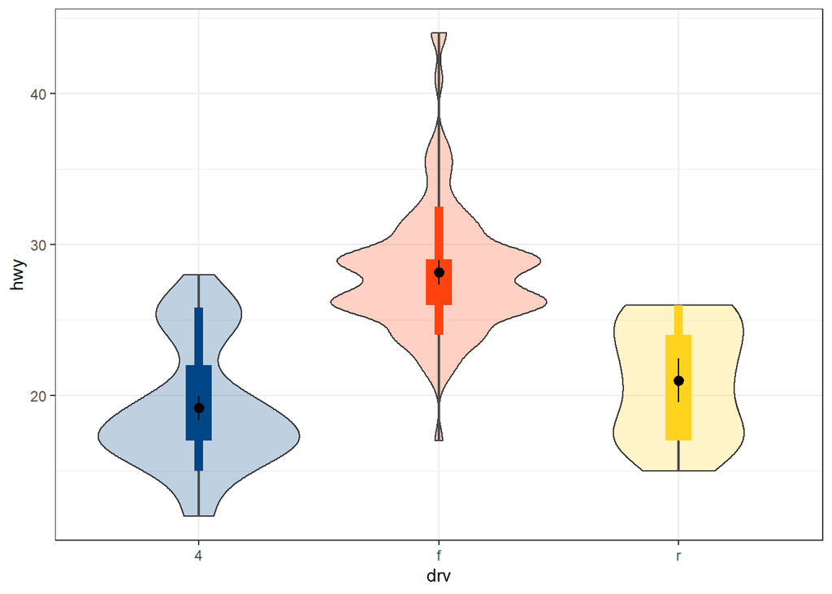

```r
mpg %>%
  ggplot(mapping = aes(x = drv, y = hwy)) +
  geom_violin(mapping = aes(fill = drv), alpha = 0.25) +
  stat_summary(geom = 'linerange',
               fun.min = 'min', fun.max = 'max',
               mapping = aes(group = drv),
               color = 'grey30', size = 0.75) +
  stat_summary(geom = 'linerange',
               fun.min = my_quantile_0.1,
               fun.max = my_quantile_0.9,
               mapping = aes(group = drv,
                             color = drv),
               size = 2.5) +
  stat_summary(geom = 'linerange',
               fun.min = my_quantile_0.25,
               fun.max = my_quantile_0.75,
               mapping = aes(group = drv,
                             color = drv),
               size = 7.5) +
  stat_summary(fun.data = "mean_se",
               color = 'black',
               fun.args = list(mult = 2)) +
  ggthemes::scale_fill_calc(guide = FALSE) +
  ggthemes::scale_color_calc(guide = FALSE) +
  theme_bw()
```

When I make these kind of figures I use an inline function.

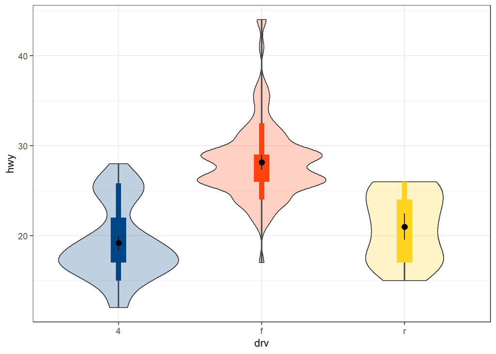

```r
mpg %>%
  ggplot(mapping = aes(x = drv, y = hwy)) +
  geom_violin(mapping = aes(fill = drv), alpha = 0.25) +
  stat_summary(geom = 'linerange',
               fun.min = 'min', fun.max = 'max',
               mapping = aes(group = drv),
               color = 'grey30', size = 0.75) +
  stat_summary(geom = 'linerange',
               fun.min = function(x){quantile(x, 0.1)},
               fun.max = function(x){quantile(x, 0.9)},
               mapping = aes(group = drv,
                             color = drv),
               size = 2.5) +
  stat_summary(geom = 'linerange',
               fun.min = function(x){quantile(x, 0.25)},
               fun.max = function(x){quantile(x, 0.75)},
               mapping = aes(group = drv,
                             color = drv),
               size = 7.5) +
  stat_summary(fun.data = "mean_se",
               color = 'black',
               fun.args = list(mult = 2)) +
  ggthemes::scale_fill_calc(guide = FALSE) +
  ggthemes::scale_color_calc(guide = FALSE) +
  theme_bw()
```

If we are only interested in the variation in the group-level averages:

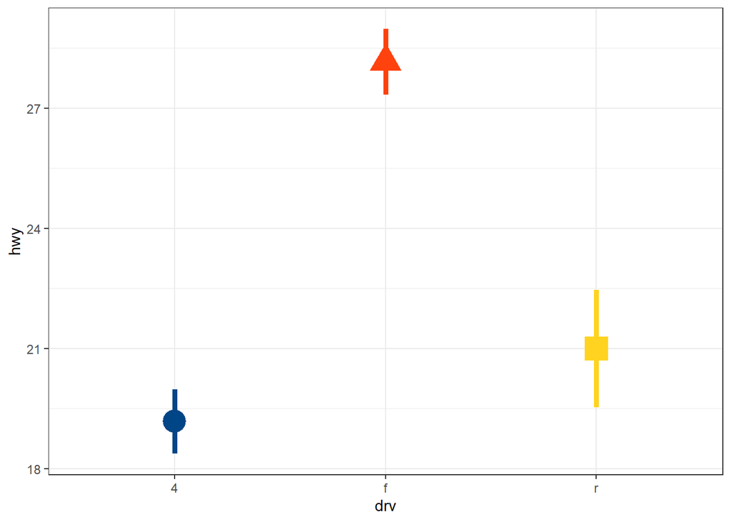

```r
mpg %>%
  ggplot(mapping = aes(x = drv, y = hwy)) +
  stat_summary(fun.data = 'mean_se',
               mapping = aes(color = drv,
                             shape = drv),
               fun.args = list(mult = 2),
               size = 1.75) +
  ggthemes::scale_color_calc(guide = FALSE) +
  scale_shape_discrete(guide = FALSE) +
  theme_bw()
```

### T-test for the Nebraska temperature data

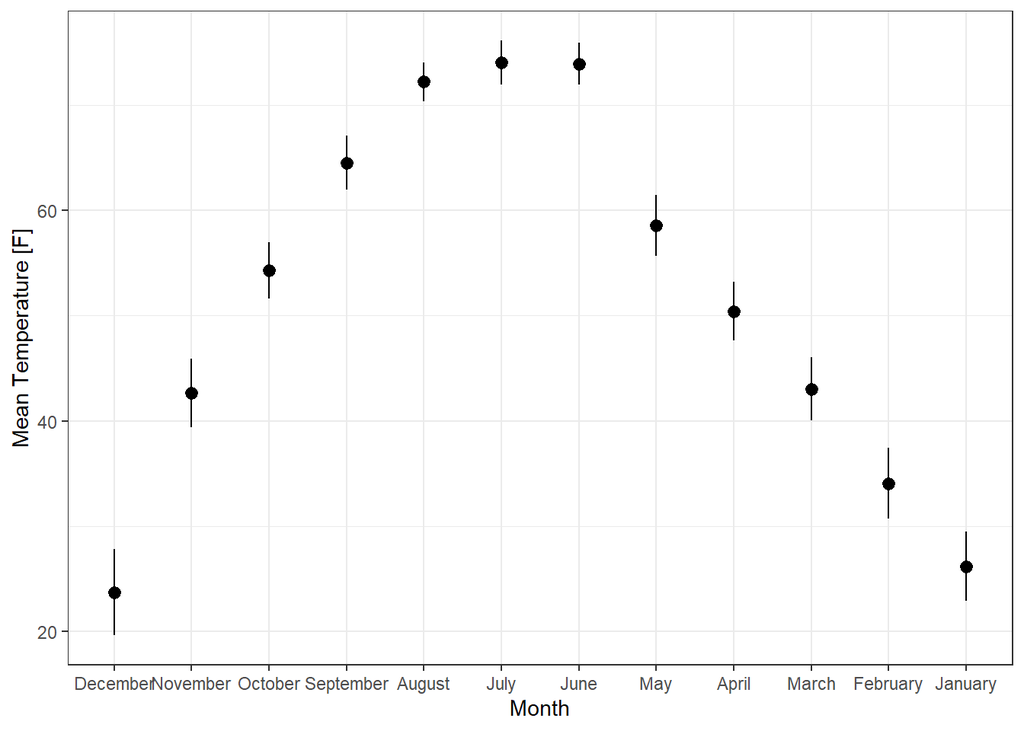

```r
lincoln_weather %>%
  ggplot(mapping = aes(x = Month, y = `Mean Temperature [F]`)) +
  stat_summary(fun.data = 'mean_se',
               fun.args = list(mult = 2)) +
  theme_bw()
```

Check the order of the levels.

```r
lincoln_weather %>%
  pull(Month) %>%
  levels()
```

```
##  [1] "December"  "November"  "October"   "September" "August"    "July"
##  [7] "June"      "May"       "April"     "March"     "February"  "January"
```

We can reverse the level order with `forcats`.

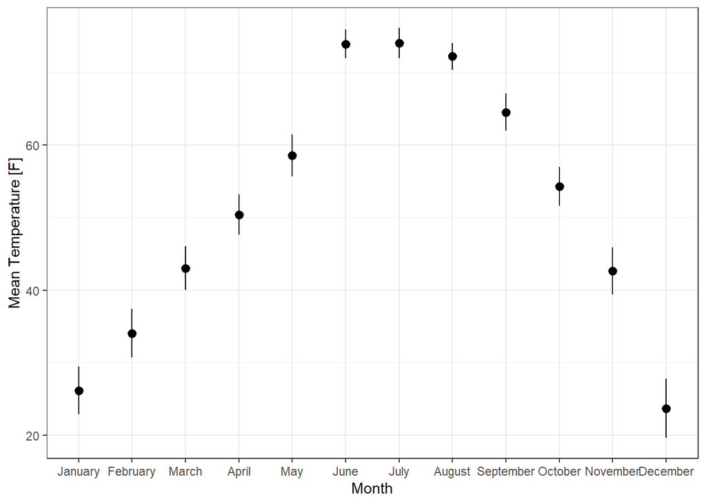

```r
lincoln_weather %>%
  mutate(Month = forcats::fct_rev(Month)) %>%
  ggplot(mapping = aes(x = Month, y = `Mean Temperature [F]`)) +
  stat_summary(fun.data = 'mean_se',
               fun.args = list(mult = 2)) +
  theme_bw()
```

Easier to **flip** the coordinate system to put the months on the y-axis.

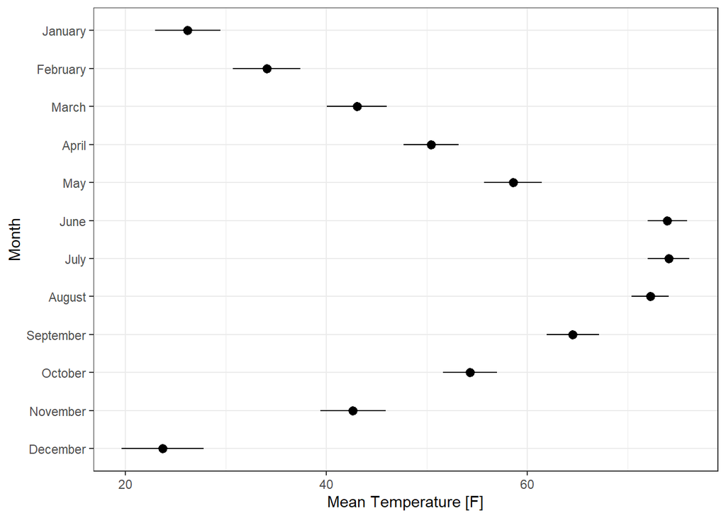

```r
lincoln_weather %>%
  # mutate(Month = forcats::fct_rev(Month)) %>%
  ggplot(mapping = aes(x = Month, y = `Mean Temperature [F]`)) +
  stat_summary(fun.data = 'mean_se',
               fun.args = list(mult = 2)) +
  coord_flip() +
  theme_bw()
```

### Visual t-test for the iris data set

```r
iris %>% glimpse()
```

```
## Rows: 150
## Columns: 5
## $ Sepal.Length <dbl> 5.1, 4.9, 4.7, 4.6, 5.0, 5.4, 4.6, 5.0, 4.4, 4.9, 5.4, 4.~
## $ Sepal.Width  <dbl> 3.5, 3.0, 3.2, 3.1, 3.6, 3.9, 3.4, 3.4, 2.9, 3.1, 3.7, 3.~
## $ Petal.Length <dbl> 1.4, 1.4, 1.3, 1.5, 1.4, 1.7, 1.4, 1.5, 1.4, 1.5, 1.5, 1.~
## $ Petal.Width  <dbl> 0.2, 0.2, 0.2, 0.2, 0.2, 0.4, 0.3, 0.2, 0.2, 0.1, 0.2, 0.~
## $ Species      <fct> setosa, setosa, setosa, setosa, setosa, setosa, setosa, s~
```

Calculate the average `Sepal.Length` per `Species` and check if there are differences in the average across `Species`.

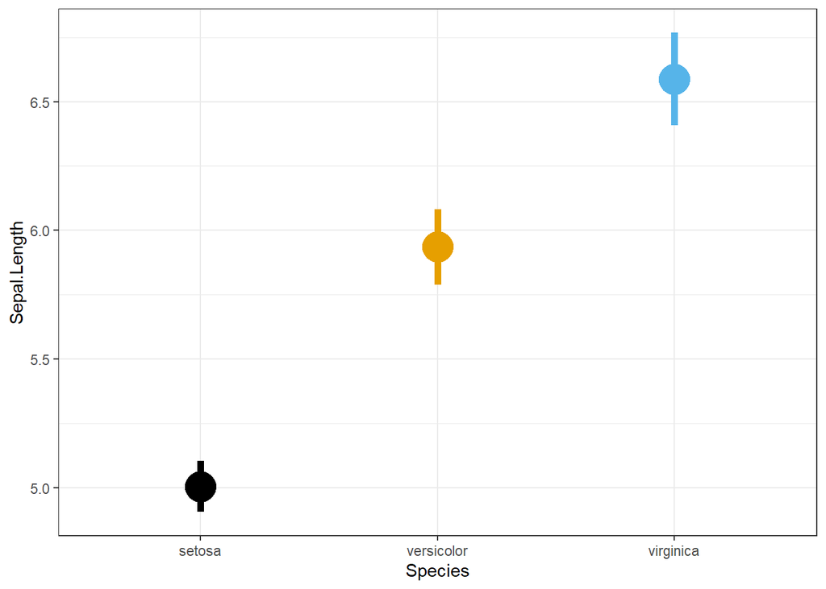

```r
iris %>%
  ggplot(mapping = aes(x = Species, y = Sepal.Length)) +
  stat_summary(fun.data = 'mean_se',
               mapping = aes(color = Species),
               fun.args = list(mult = 2),
               size = 2) +
  ggthemes::scale_color_colorblind(guide = FALSE) +
  theme_bw()
```

## Continuous variable relationships

Looked at the correlation coefficient between the `Sepal` variables.

```r
iris %>%
  select(starts_with("Sepal.")) %>%
  cor()
```

```
##              Sepal.Length Sepal.Width
## Sepal.Length    1.0000000  -0.1175698
## Sepal.Width    -0.1175698   1.0000000
```

Looked at the correlation coefficient **grouped by** `Species`.

```r
iris %>%
  select(Species, starts_with("Sepal.")) %>%
  group_by(Species) %>%
  group_modify( ~ as.data.frame(cor(.x)))
```

```
## # A tibble: 6 x 3
## # Groups:   Species [3]
##   Species    Sepal.Length Sepal.Width
##   <fct>             <dbl>       <dbl>
## 1 setosa            1           0.743
## 2 setosa            0.743       1
## 3 versicolor        1           0.526
## 4 versicolor        0.526       1
## 5 virginica         1           0.457
## 6 virginica         0.457       1
```

Visualizing correlation plots can streamline understanding the linear relationship across many **pairs** of variables.

```r
iris %>%
  purrr::keep(is.numeric) %>%
  cor()
```

```
##              Sepal.Length Sepal.Width Petal.Length Petal.Width
## Sepal.Length    1.0000000  -0.1175698    0.8717538   0.8179411
## Sepal.Width    -0.1175698   1.0000000   -0.4284401  -0.3661259
## Petal.Length    0.8717538  -0.4284401    1.0000000   0.9628654
## Petal.Width     0.8179411  -0.3661259    0.9628654   1.0000000
```

### Sonar data

Need the `mlbench` package.

```r
data("Sonar", package = 'mlbench')
```

```r
Sonar %>% dim()
```

```
## [1] 208  61
```

```r
Sonar %>% purrr::map_chr(class)
```

```
##        V1        V2        V3        V4        V5        V6        V7        V8
## "numeric" "numeric" "numeric" "numeric" "numeric" "numeric" "numeric" "numeric"
##        V9       V10       V11       V12       V13       V14       V15       V16
## "numeric" "numeric" "numeric" "numeric" "numeric" "numeric" "numeric" "numeric"
##       V17       V18       V19       V20       V21       V22       V23       V24
## "numeric" "numeric" "numeric" "numeric" "numeric" "numeric" "numeric" "numeric"
##       V25       V26       V27       V28       V29       V30       V31       V32
## "numeric" "numeric" "numeric" "numeric" "numeric" "numeric" "numeric" "numeric"
##       V33       V34       V35       V36       V37       V38       V39       V40
## "numeric" "numeric" "numeric" "numeric" "numeric" "numeric" "numeric" "numeric"
##       V41       V42       V43       V44       V45       V46       V47       V48
## "numeric" "numeric" "numeric" "numeric" "numeric" "numeric" "numeric" "numeric"
##       V49       V50       V51       V52       V53       V54       V55       V56
## "numeric" "numeric" "numeric" "numeric" "numeric" "numeric" "numeric" "numeric"
##       V57       V58       V59       V60     Class
## "numeric" "numeric" "numeric" "numeric"  "factor"
```

Check the correlation between every pair of variables.

```r
Sonar %>%
  purrr::keep(is.numeric) %>%
  cor() %>%
  dim()
```

```
## [1] 60 60
```

Visualize the correlation plot using `corrplot`.

```r
library(corrplot)
```

`corrplot` has a main function `corrplot()` that requires a correlation matrix as input.

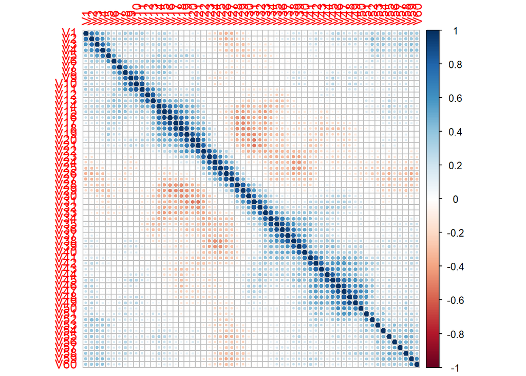

```r
Sonar %>%
  purrr::keep(is.numeric) %>%
  cor() %>%
  corrplot::corrplot()
```

When there are many variables I prefer to use the squares instead of circles.

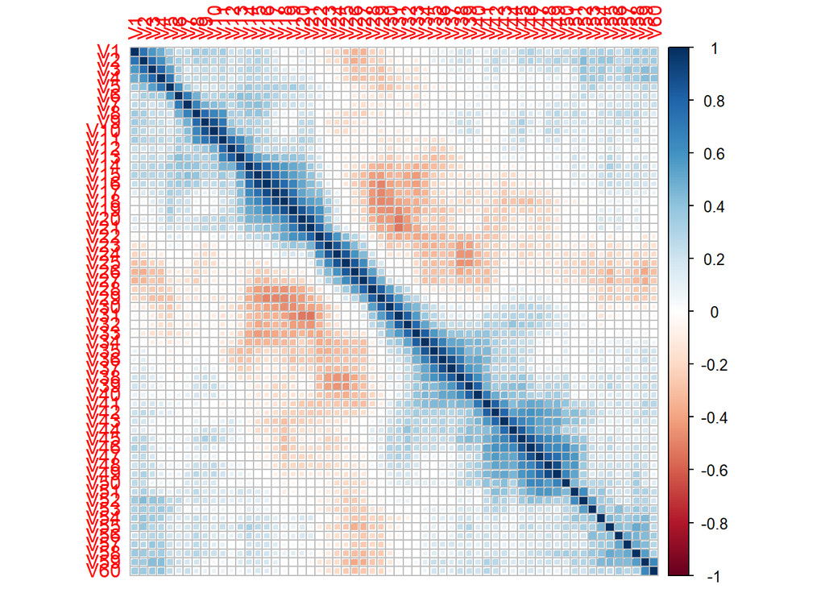

```r
Sonar %>%
  purrr::keep(is.numeric) %>%
  cor() %>%
  corrplot::corrplot(method = 'square')
```

Can just show a upper triangular plot.

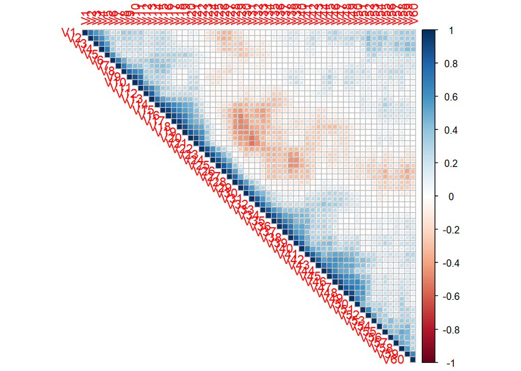

```r
Sonar %>%
  purrr::keep(is.numeric) %>%
  cor() %>%
  corrplot::corrplot(method = 'square', type = 'upper')
```

We can reorganize the variables based on **groups** or **clusters** of variables.

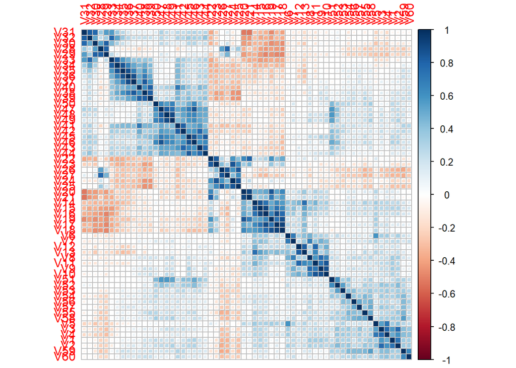

```r
Sonar %>%
  purrr::keep(is.numeric) %>%
  cor() %>%
  corrplot::corrplot(method = 'square', order = 'hclust')
```

By default the complete linkage is used, but I prefer the Ward method.

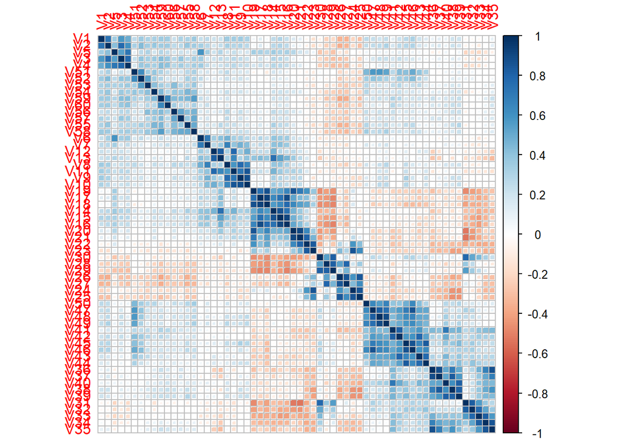

```r
Sonar %>%
  purrr::keep(is.numeric) %>%
  cor() %>%
  corrplot::corrplot(method = 'square', order = 'hclust', hclust.method = 'ward.D2')
```

Lastly we can draw rectangles around the clusters.

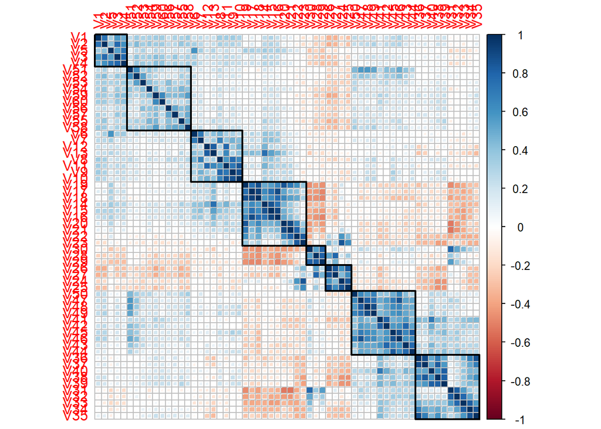

```r
Sonar %>%
  purrr::keep(is.numeric) %>%
  cor() %>%
  corrplot::corrplot(method = 'square', order = 'hclust', hclust.method = 'ward.D2',
                     addrect=8)
```

With smaller data sets like `iris` we can show the correlation coefficient value directly.

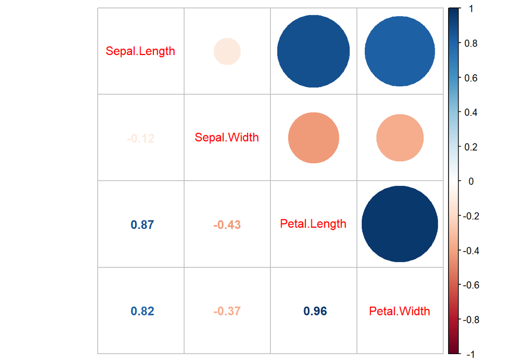

```r
iris %>%
  purrr::keep(is.numeric) %>%
  cor() %>%
  corrplot::corrplot.mixed()
```